# Solution for Tim’s Project

Julia Siodmiak

2025-12-16

**Spaltenerklärung der LUBW:**

- id: Schlüssel für Bundesland, Naturraum, Kreis oder Gemeinde name
- Bezeichnung typ: Bundesland, Naturraum, Kreis oder Gemeinde
- Kalenderjahr, Jahreszeiten oder Monate jahr: Jahr
- temperatur_heisse_tage: Anzahl Heißer Tage (Tmax ≥ 30 °C)
- temperatur_frosttage: Anzahl Frosttage (Tmin ≤ 0 °C)
- temperatur_tropennaechte: Anzahl Tropennächte (Tmin ≥ 20 °C)
- temperatur_mittelwert: Temperatur (°C)
- temperatur_heizgradtage: Heizgradtage (Kelvin x Tage)
- temperatur_kuehlgradtage: Kühlgradtage (Kelvin x Tage)
- niederschlag_summe: Niederschlagssumme (Millimeter)
- starkniederschlag_20mm_tage: Anzahl Tage mit N ≥ 20 mm
- trockenperiode_tage_maximum: Dauer der längsten Trockenperiode mit Tagen < 1 mm

# Solutions

- Wie veränderte sich die Temperatur im zeitlichen Verlauf?

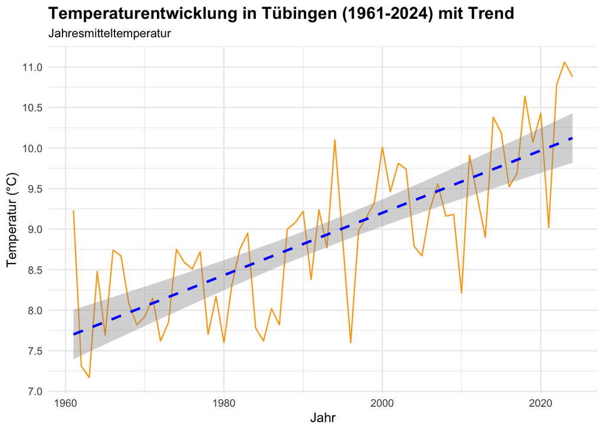

- Wie verändert sich die Temperatur im Jahreszeitlichen Verlauf, über den gesamten Messzeitraum?

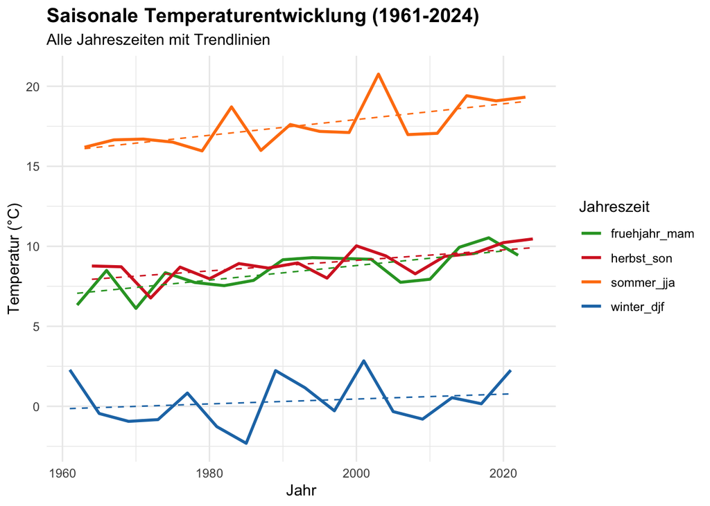

- Wie verhalten sich die Niederschlagsmengen in Kombination mit den Heißen Tagen?

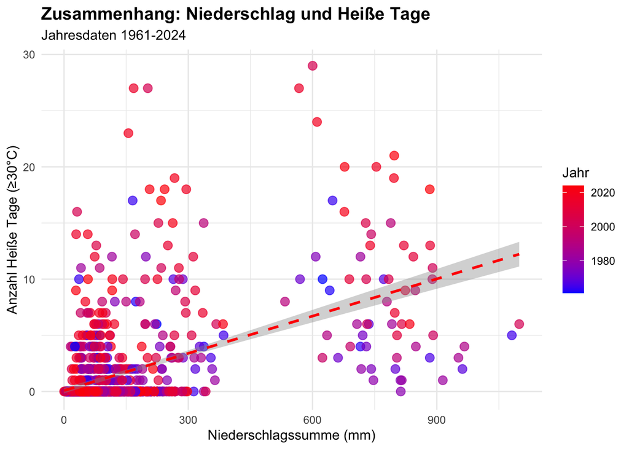

Die Korrelation zwischen Niederschlag und heißen Tagen beträgt `0.506` .

- Wie entwickeln sich die Heißtage und Frost im laufe der Zeit und Sasional?

[figure not shown]

Saisonale Trenddiagramme, alle Saisons in einem Diagramm

[figure not shown]

- Wie sieht der Mittelwert im Jahr 2023 aus?

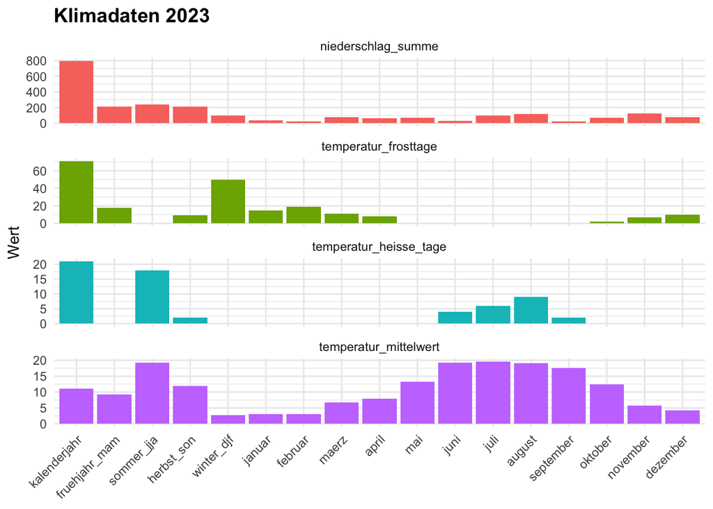

Darstellung mithilfe einer Heatmap

- Wie häufig treten Trockenperioden auf und wie lange dauern diese an?

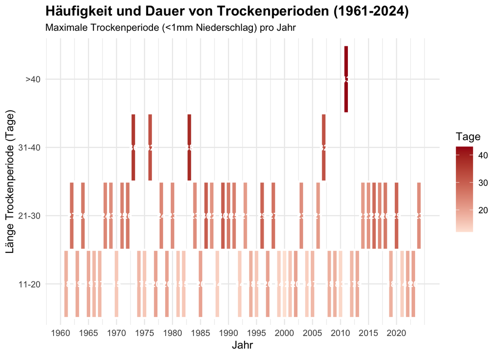

Heatmap, Barplot

- Gibt es einen Zusammenhang zwischen Tropennächten und Trockentagen?

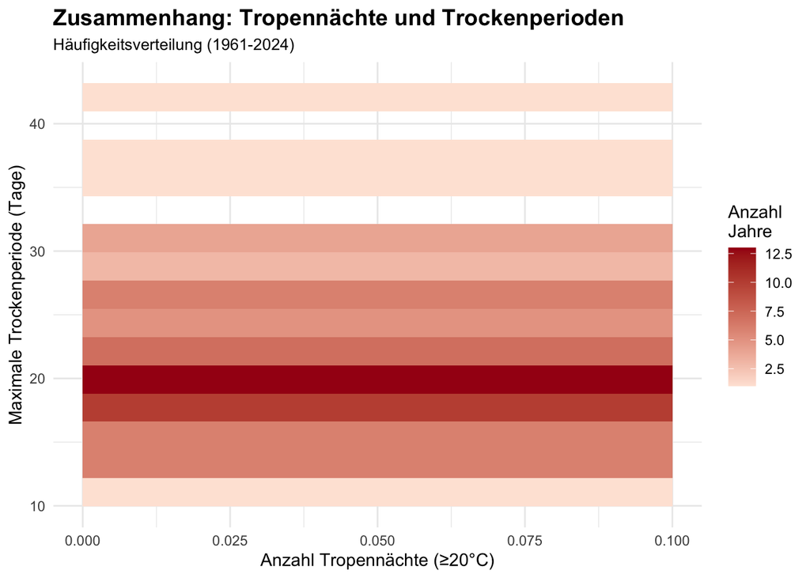

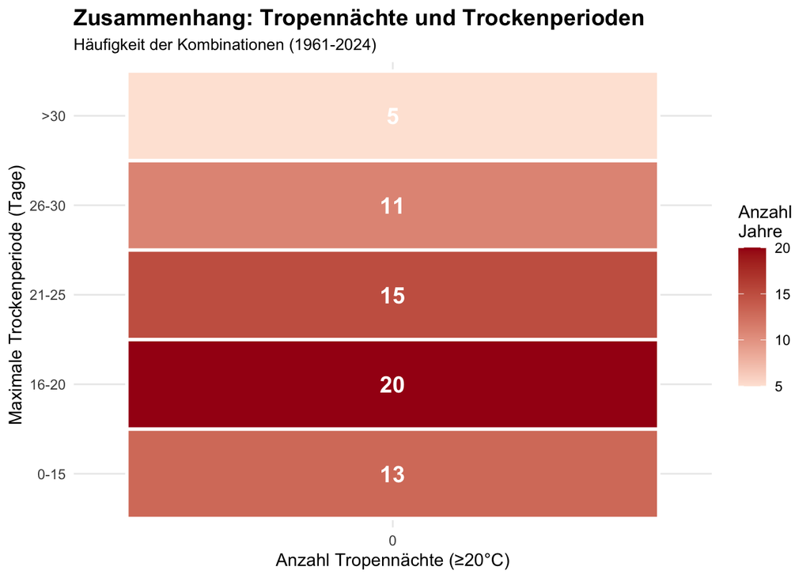

Korrelationsmatrix und Scatterplot, gerne auch andere Dimensionen

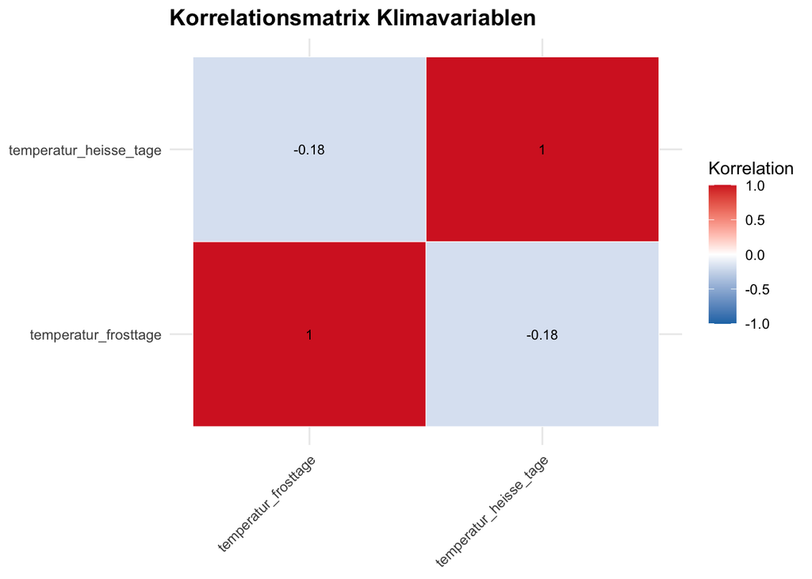

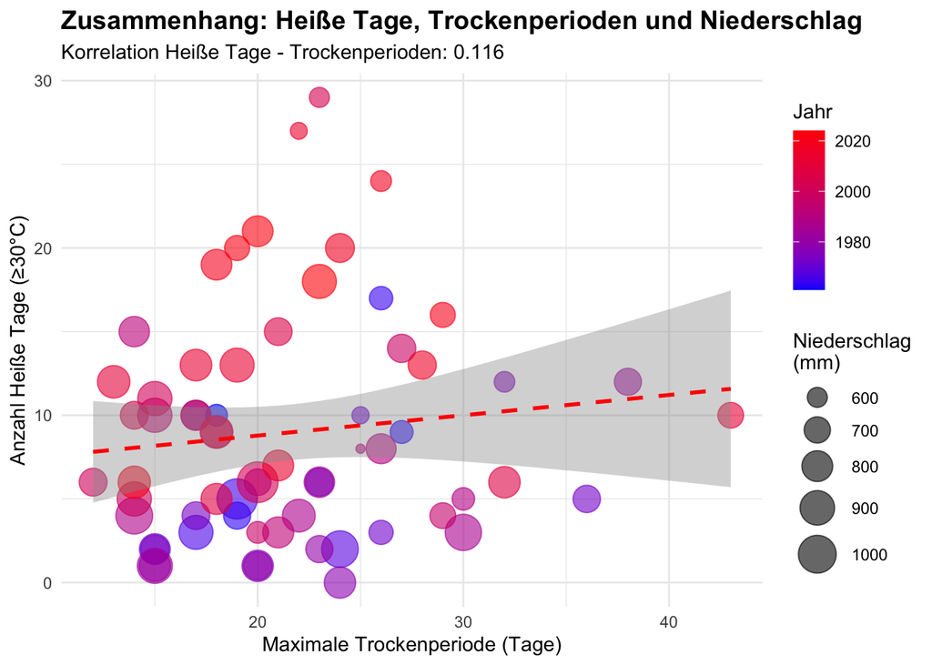

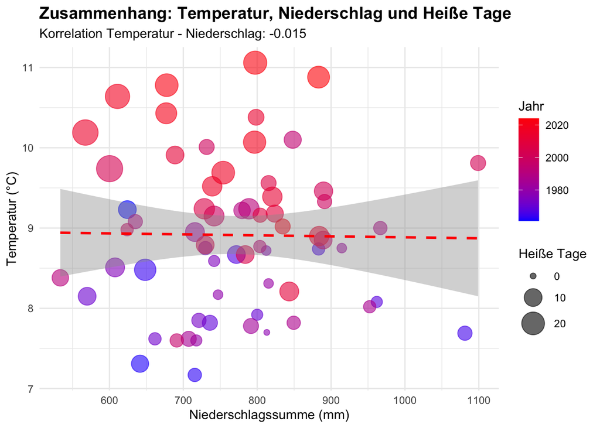

- Hat die Anzahl an Starknierderschlägen über die Jahre zugenommen? Wenn ja, wie viele Starkniederschläge gab es und wie verteilen sich diese über das Jahr?

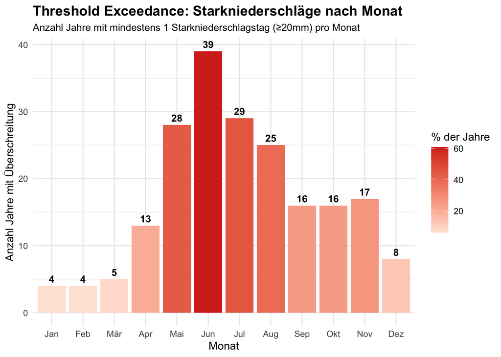

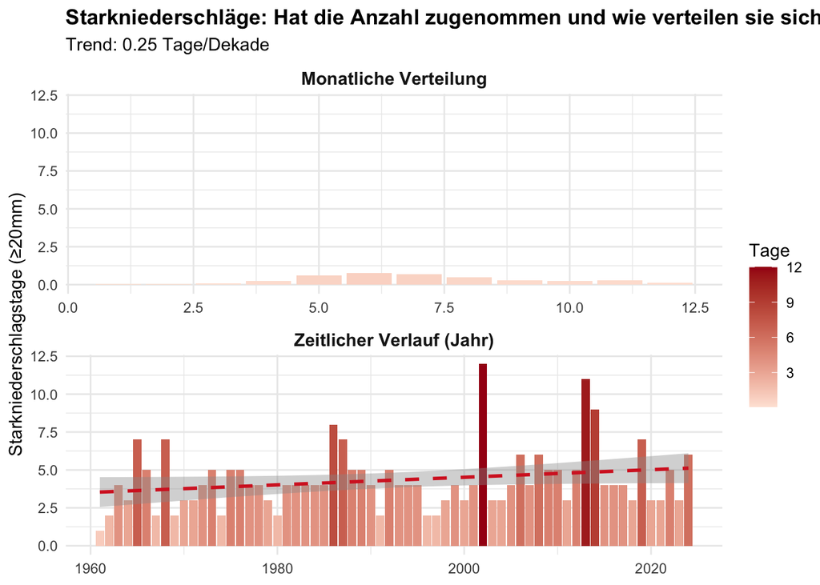